# COMPSCIX 415.2 Homework 2

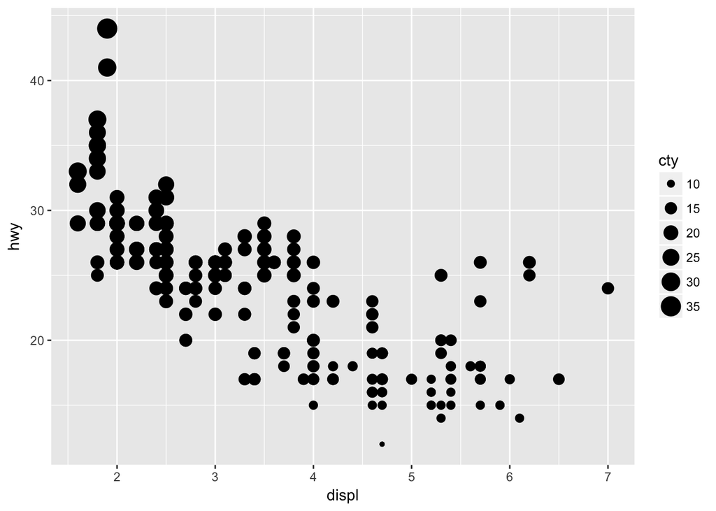

```r
ggplot(data = mpg) +
  geom_point(mapping = aes(x = displ, y = hwy, size = cty))
```

```r
ggplot(data = mpg) +
  geom_point(mapping = aes(x = displ, y = hwy, shape = cty))
#This gives an error
```

4. If you map the same variable to multiple aesthetics, it will just apply them all to the variable. It will apply the same aesthetics as if only one was assigned. For example, it will give it the same shade of blue as it was given when you only map color, and it will give it the same size when you only map size, but it will give both to this variable.

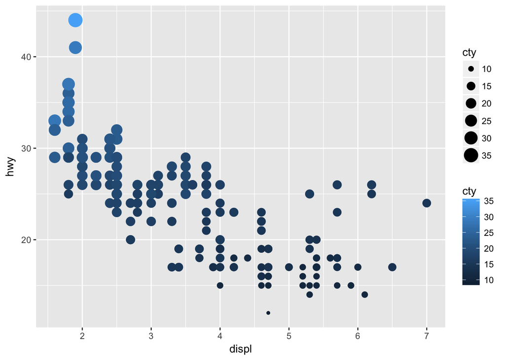

```r
ggplot(data = mpg) +
  geom_point(mapping = aes(x = displ, y = hwy, color = cty, size = cty))
```

5. The stroke aesthetic changes the width of the border of each point. It works for every shape in the diagram in the R for Data Science reading. Some shapes do look better when increasing the stroke, while some become more of a blob quicker.

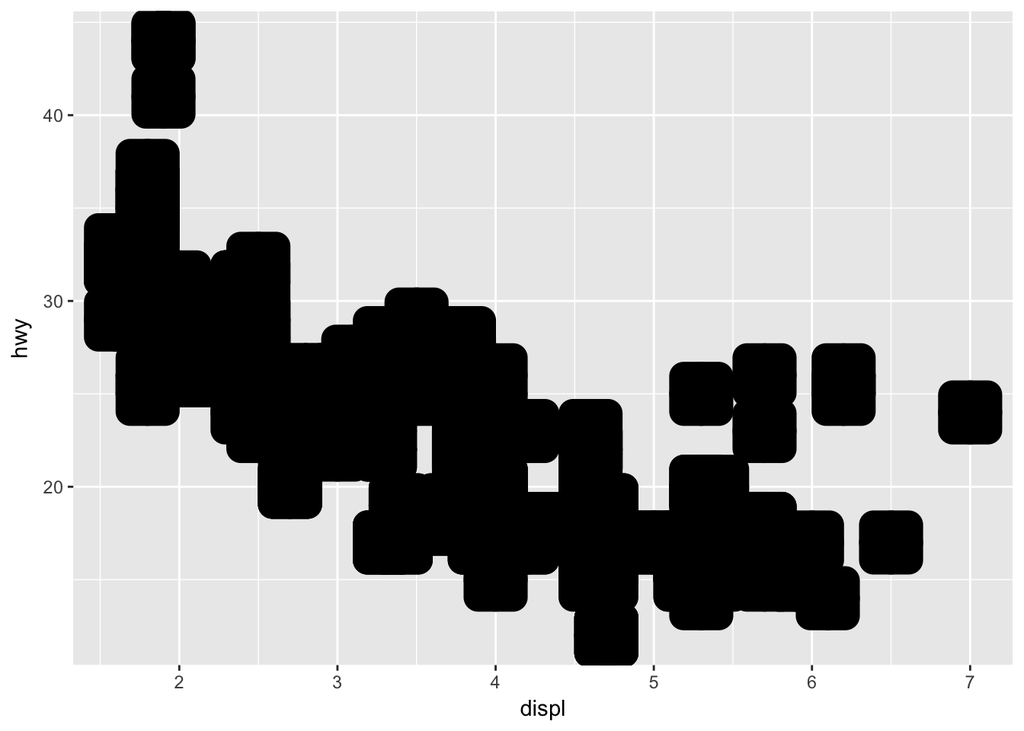

```r
ggplot(data = mpg) +
  geom_point(mapping = aes(x = displ, y = hwy,  stroke = 10), shape = 12)
```

6. If you just assign an aesthetic without assigning an x and y, it will give you an error. If you do assign an x and y, then it will assign the aesthetic according to the requirements you state. For example, the question asks us to test color = displ < 5. As can be seen in the graph below, it assigns all points that have a displ less than 5 to one color and everything else another color. The same works for shape and size, but it will give you a warning that size is not recommended.

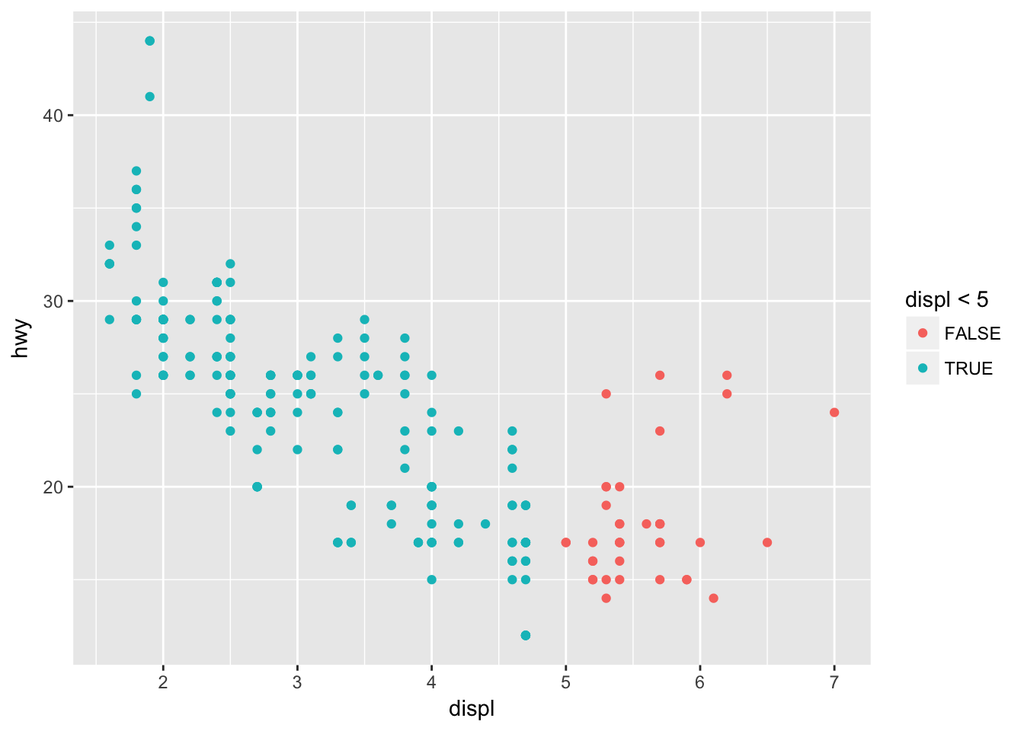

```r
ggplot(data = mpg) +
  geom_point(mapping = aes(x = displ, y = hwy, color = displ < 5))
```

3.5.1

4. The immediate advantage I can see by using facets instead of colors is that you can easily separate out each type. In this case, we can clearly see where the points are for each class of car. Another one, is that each subplot is less cluttered. The disadvantage I can see is that it may be a bit more difficult to compare types as you’ll need to take a look at two subplots as opposed to one.

In regards to a larger dataset, it depends on what that entails. If this means that there are more classes of cars, then I think I’d prefer to use color as having too many facets can be hard to read. If it means that there are simply more entries, but no increase in classes, I believe facet will be easier to read as each subplot will be less cluttered.

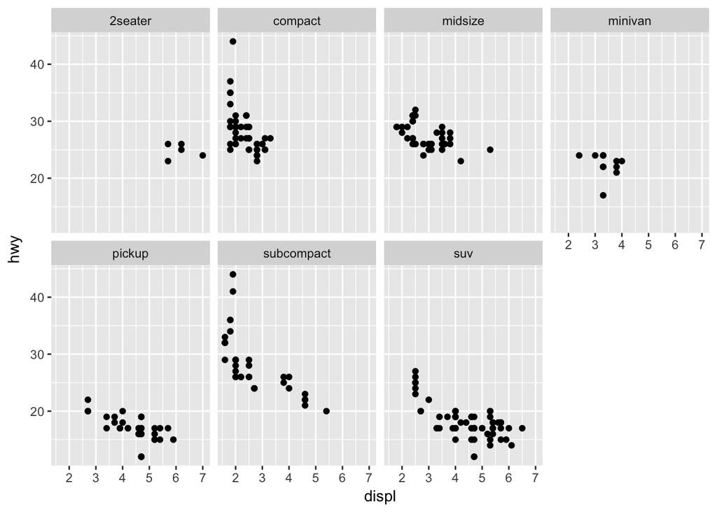

```r
ggplot(data = mpg) +
geom_point(mapping = aes(x = displ, y = hwy)) +
  facet_wrap(~ class, nrow = 2)
```

5. nrow assigns the number of rows you want (so in the previous question, nrow = 2 gives us two rows). ncol assigns the number of columns of subplots there are (previous question had 4 columns, but we didn’t need put it in).

Other options that affect the layout are if we add another variable to the facet (I understand that we can also use facet_grid instead). You can also use dir to change the direction. A facet_grid does not accept nrows or ncols as arguments because the number of rows and columns is already determined by the number of unique types in each class. In the second facet below, you can see since drv has 3 types, it determines that there are 3 rows. There are 7 types of classes, so that determines the columns.

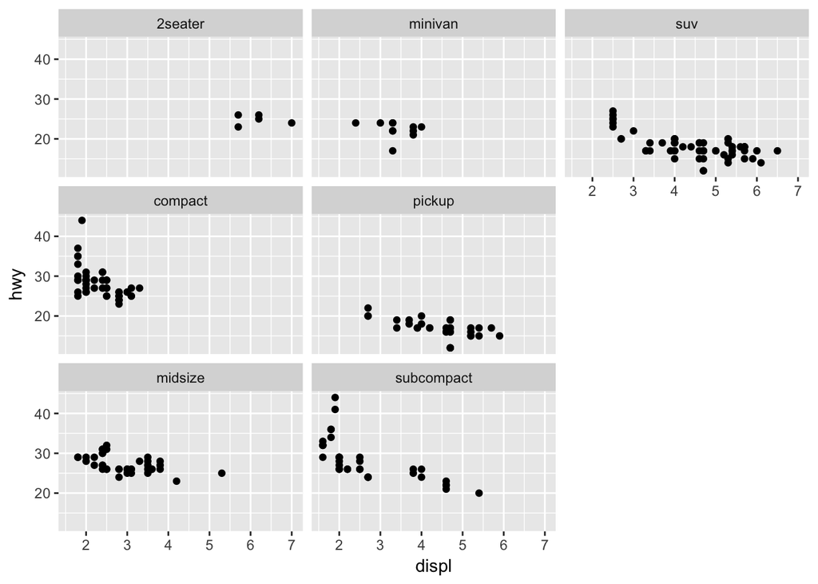

```r
ggplot(data = mpg) +
geom_point(mapping = aes(x = displ, y = hwy)) +
  facet_wrap(~ class, dir = "v")
```

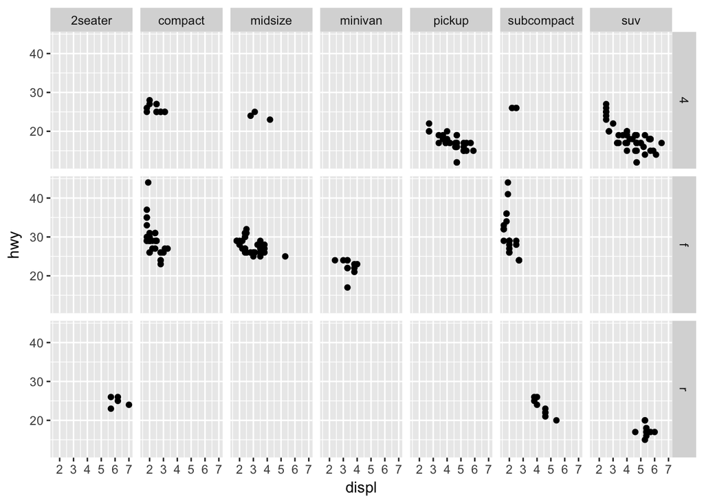

```r
ggplot(data = mpg) +
geom_point(mapping = aes(x = displ, y = hwy)) +
  facet_grid(drv ~ class)
```

3.6.1

1. For a line chart I would use geom_line. For a boxplot I would use geom_boxplot. For a histogram I would use geom_histogram. Finally, for an area chart I would use geom_area.
2. There wasn’t really a question to answer here, but I did the exercise.

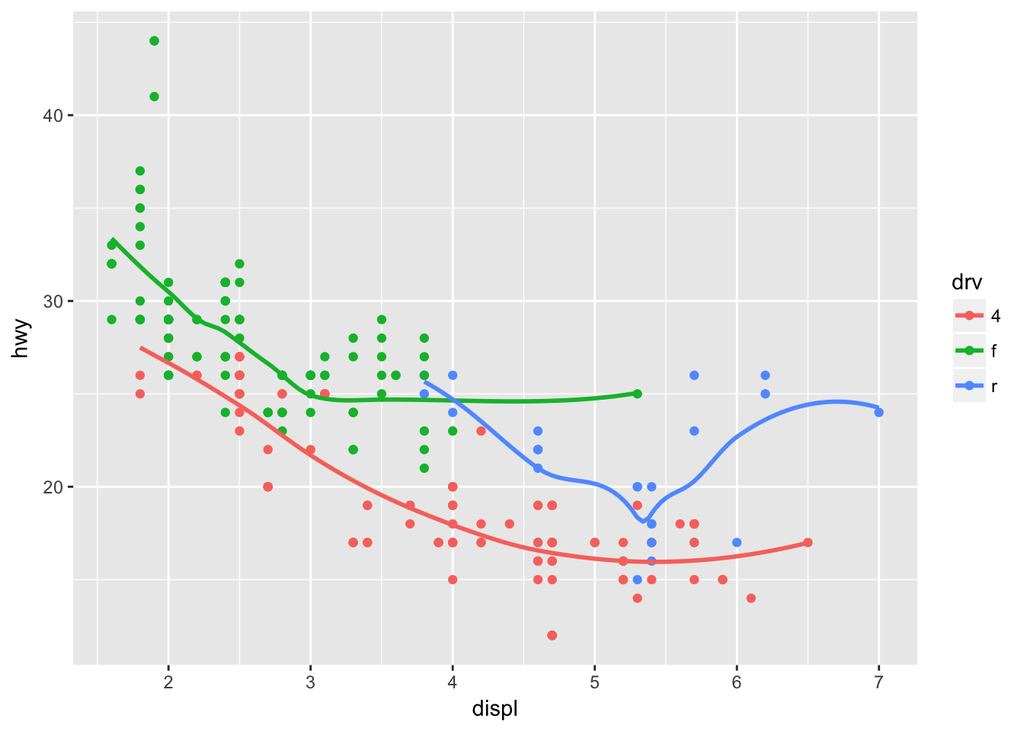

```r
ggplot(data = mpg, mapping = aes(x = displ, y = hwy, color = drv)) +
  geom_point() +
  geom_smooth(se = FALSE)
```

3. show.legend = FALSE removes the legend if it is there for that specific layer it is included in. The legend shows what each aesthetic represents. If you take it out, it defaults to showing the legend. It might have been used earlier in the chapter to have less clutter in the plot.
4. The se argument determines if the confidence interval around the smooth line is displayed. It is displayed by default.
5. The two graphs will look the same. This is because all the necessary information can be placed in different sections of the code depending on how much you want to type. The first code chunk has it all in the first line. If you dont want include it in the ggplot line, then you’ll need to type it in each additional layer. So for example in the second code chunk, if you only type it in geom_point and not in geom_smooth, then the smooth line is not displayed.

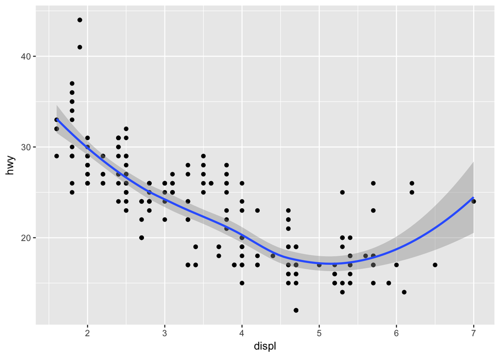

```r
ggplot(data = mpg, mapping = aes(x = displ, y = hwy)) +
  geom_point() +
  geom_smooth()
```

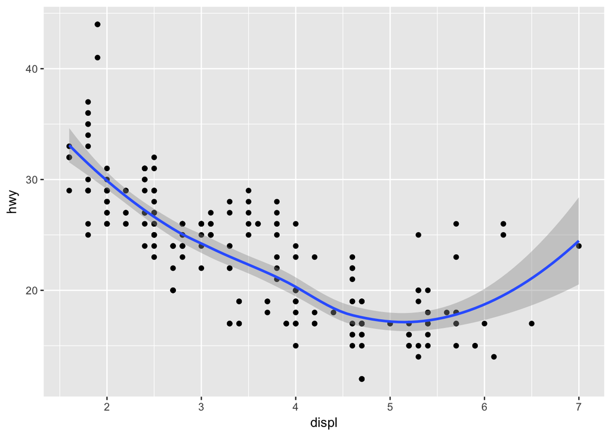

```r
ggplot() +
  geom_point(data = mpg, mapping = aes(x = displ, y = hwy)) +
  geom_smooth(data = mpg, mapping = aes(x = displ, y = hwy))
```

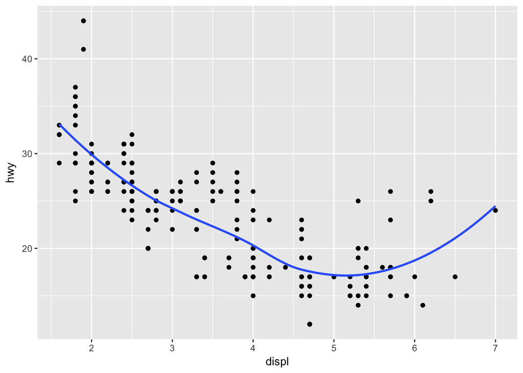

```r
ggplot(data = mpg, mapping = aes(x = displ, y = hwy)) +
  geom_point() +
  geom_smooth(se = FALSE)
```

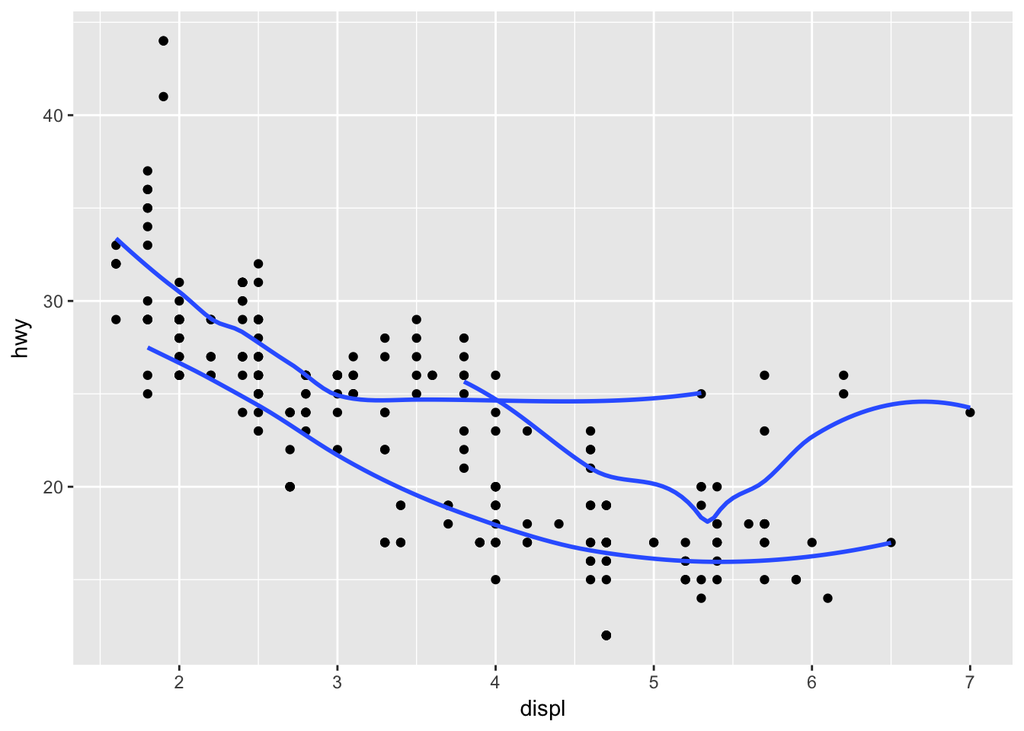

```r
ggplot(data = mpg, mapping = aes(x = displ, y = hwy, group = drv)) +
  geom_point() +
  geom_smooth(se = FALSE)
```

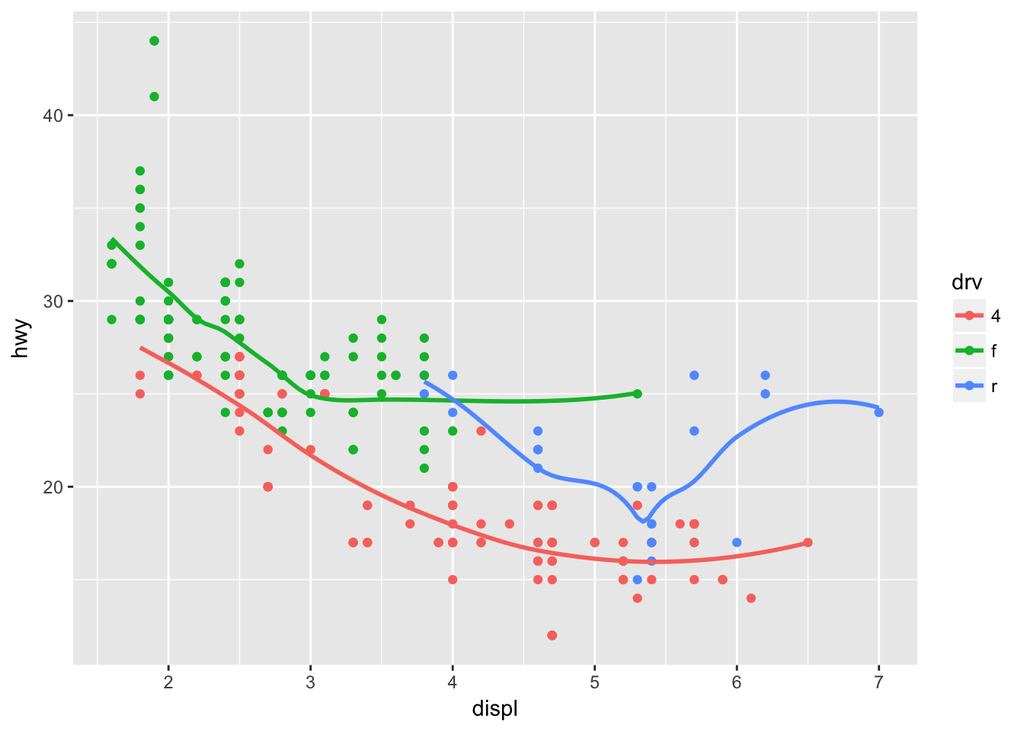

```r
ggplot(data = mpg, mapping = aes(x = displ, y = hwy, group = drv, color = drv)) +
  geom_point() +
  geom_smooth(se = FALSE)
```

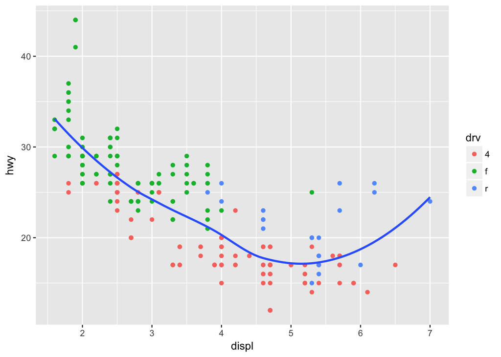

```r
ggplot(data = mpg) +
  geom_point(mapping = aes(x = displ, y = hwy, color = drv)) +
  geom_smooth(mapping = aes(x = displ, y = hwy), se = FALSE)
```

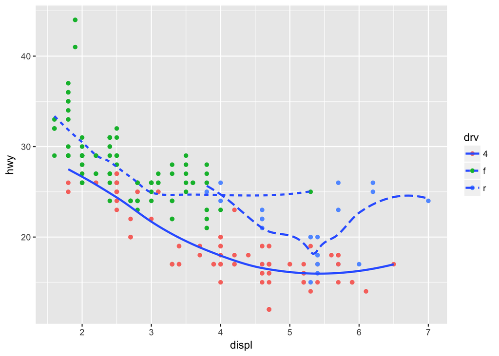

```r
ggplot(data = mpg) +
  geom_point(mapping = aes(x = displ, y = hwy, color = drv)) +
  geom_smooth(mapping = aes(x= displ, y = hwy, linetype = drv), se = FALSE)
```

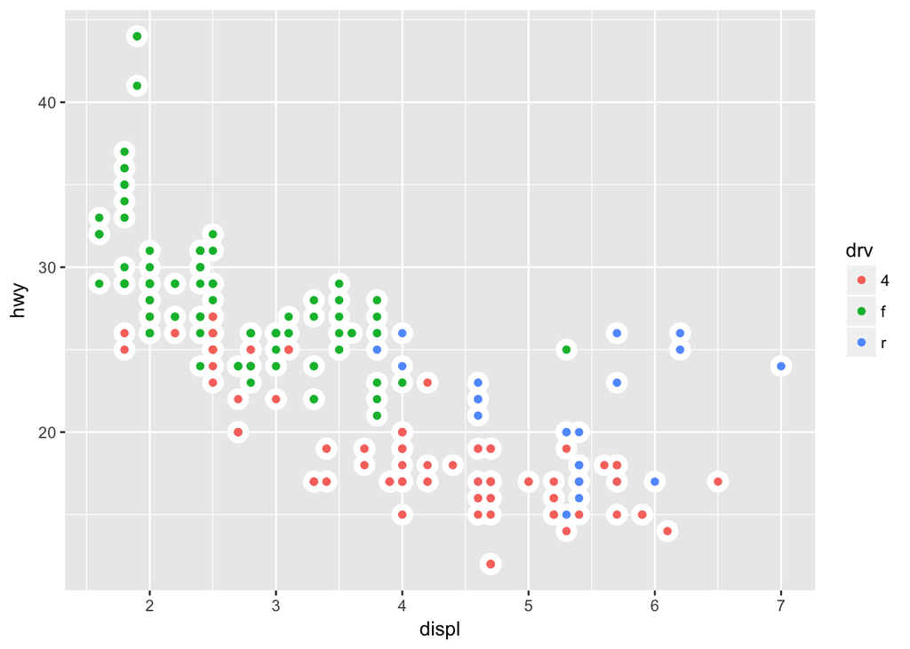

```r
ggplot(data = mpg) +
  geom_point(mapping = aes(x = displ, y = hwy), color = "white", size = 5) +
  geom_point(mapping = aes(x = displ, y = hwy, color = drv))
```

3.7.1

2. geom_col adds up every value in each category. It is different than geom_bar in some ways. For example, geom_col requires both an x and y variable. In the second plot it will add each price in each cut category and add it together, while geom_bar just counts how many rows are in each cut category.

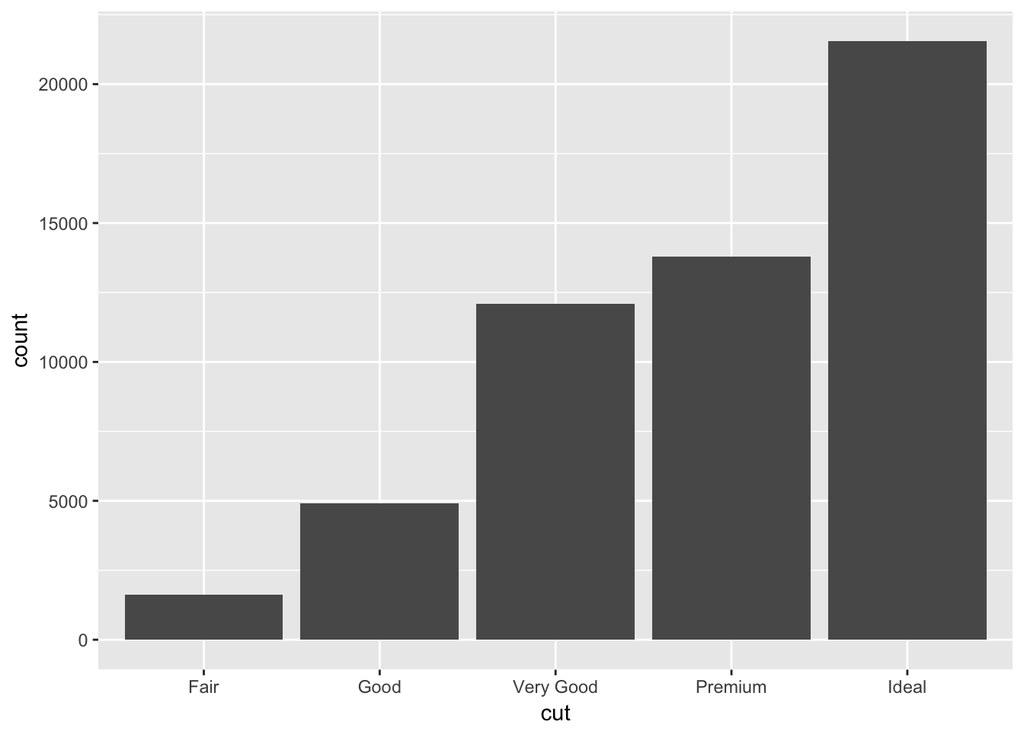

```r
ggplot(data = diamonds) +
  geom_bar(mapping = aes(x = cut))
```

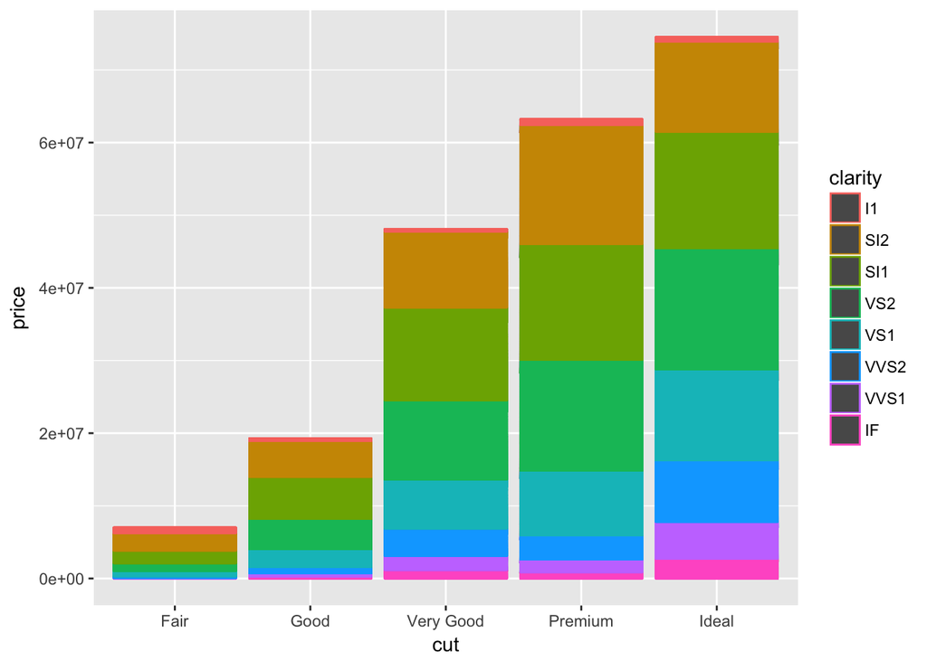

```r
ggplot(data = diamonds) +
  geom_col(mapping = aes(x = cut, y = price, color = clarity))
```

Answer these questions:  
1. There are a couple of things I like and dislike about this graphic on data scientists.  
Dislikes:  
-I do not like the background choice of having the grid. I would pick a solid white color or something less distracting  
-The second graphic with the different squares, is a strange way to display this data. Due to being two dimensions, a category may look much smaller than the percents really show. For example the two middle squares only differ by 3%, yet it looks like it’s much smaller. I’d take a look at maybe using a horizontal bar graph  
-The third graphic with the fading percentages is also a strange design choice. This could easily just be a regular table  
-The second bar chart graphic comparing what each are more likely to be involved in. It just shows that the data scientists are more likely to do everything. I can’t get anything out of these percentages  
-The final graphic is confusing. The label above states it is who the data scientist works with. But then the label on the right of the graphic seems to suggest that the graphic is a data science team break down. Taking a further look, what do the percents even mean? They don’t add up to 100% obviously, so what do the represent?

Likes:  
-The graphic with the different size circles. You can clearly see the percentage differences -They remain consistent in the color scheme for Data Scientist vs. Business Intelligence

Things I’d Change:  
-There are some sections that could use a table instead  
-I would elaborate on some of the data and percentages as they don’t immediately make sense -I know we talked about how pie charts aren’t usually very effective, but I would say out of the problems in this graphic, the pie charts are actually ok. I probably would have done a different graphic, but they’re not the most glaring problems.